# **Music Recommendation System**

## **Exploratory Data Analysis**

### **Let's check the total number of unique users, songs, artists in the data**

Total number of unique user id

```python
df_final.columns
```

```
Index(['user_id', 'song_id', 'play_count', 'title', 'release', 'artist_name',
       'year'],
      dtype='object')
```

```python
df_final.shape
```

```
(117876, 7)
```

```python
# Display total number of unique user_id
df_final['user_id'].nunique()
```

```
3155
```

Total number of unique song id

```python
# Display total number of unique song_id
df_final['song_id'].nunique()
```

```
563
```

Total number of unique artists

```python
# Display total number of unique artists
df_final['artist_name'].nunique()
```

```
232
```

```python
round((df_final.shape[0]/((df_final['user_id'].nunique())*(df_final['song_id'].nunique())))*100,2)
```

```
6.64
```

#### **Observations and Insights:**

- There are only 232 Unique artists
- With a count of 3155 Unique users, and 563 Unique Songs, there are total 1,776,265 possible interactions, but we have only 117876 interactions in our dataset. So, only 6.64% of the interactions is availble.

### **Let's find out about the most interacted songs and interacted users**

Most interacted songs

```python
# Top 10 most interacted songs
df_final.groupby('song_id').size().sort_values(ascending=False)[:10]
```

```
song_id
8582    751
352     748
2220    713
1118    662
4152    652
5531    618
4448    609
6189    606
6293    583
1334    570
dtype: int64
```

```python
df_final['song_id'].value_counts()
```

```
8582    751
352     748
2220    713
1118    662
4152    652
       ...
9048    103
6450    102
990     101
4831     97
8324     96
Name: song_id, Length: 563, dtype: int64
```

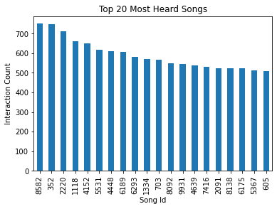

```python
df_final.groupby('song_id').size().sort_values(ascending=False)[:20].plot(kind='bar')
plt.xlabel('Song Id')
plt.ylabel('Interaction Count')
plt.title("Top 20 Most Heard Songs")
```

Most interacted users

```python
# Top 10 active users
df_final.groupby('user_id').size().sort_values(ascending=False)[:10]
```

```
user_id
61472    243
15733    227
37049    202
9570     184
23337    177
10763    176
9097     175
26616    175
43041    174
65994    171
dtype: int64
```

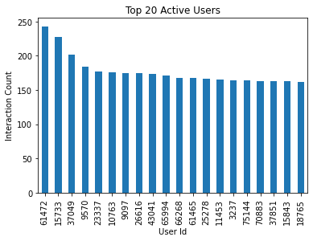

```python
df_final.groupby('user_id').size().sort_values(ascending=False)[:20].plot(kind='bar')
plt.xlabel('User Id')
plt.ylabel('Interaction Count')
plt.title("Top 20 Active Users")
```

#### **Observations and Insights:**

- Song with id 8582 is the most heard song (most interacted song), where as user id 61472 is the most active user listening to the songs (Most interacted user)
- These top 20 Users an be granted special discounts/ offers so that they continue to remain reliable customers.
- In rank based recommendation systems and to solve cold start problem, the top 20 interacted songs can be useful to recommend users these songs.
- Cold Start Problem: When a user is new, and has not interacted much/ heard any songs, and very little information is known about user

Songs played in a year

- Please note: Year column indicates the release year of the song and not the year in which user heard (played) the song, so the below count will give an estimate of number of songs released and heard by users in that pparticular year
- But in reality, users might have also played the songs which were released in previous years! ( the data for which is not available)

```python
count_songs = df_final.groupby('year').count()['title']

count = pd.DataFrame(count_songs)

count.drop(count.index[0], inplace = True)

count.tail()
```

| year | title |
| --- | --- |
| 2006 | 7592 |
| 2007 | 13750 |
| 2008 | 14031 |
| 2009 | 16351 |
| 2010 | 4087 |

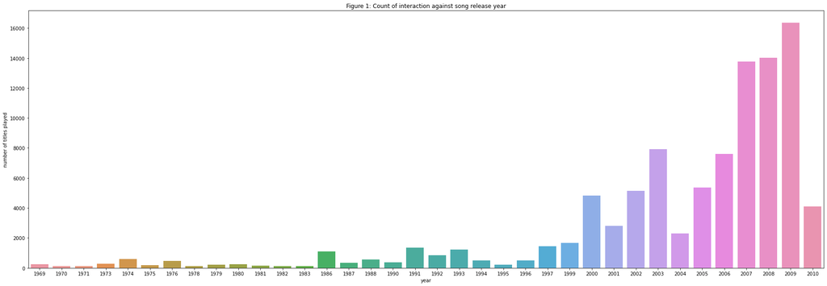

```python
# Create the plot

# Set the figure size
plt.figure(figsize = (30, 10))

sns.barplot(x = count.index,
            y = 'title',
            data = count,
            estimator = np.median)

# Set the y label of the plot
plt.ylabel('number of titles played')
plt.title('Figure 1: Count of interaction against song release year')
# Show the plot
plt.show()
```

- The below chart focuses on the releases every year from 1969 to 2011

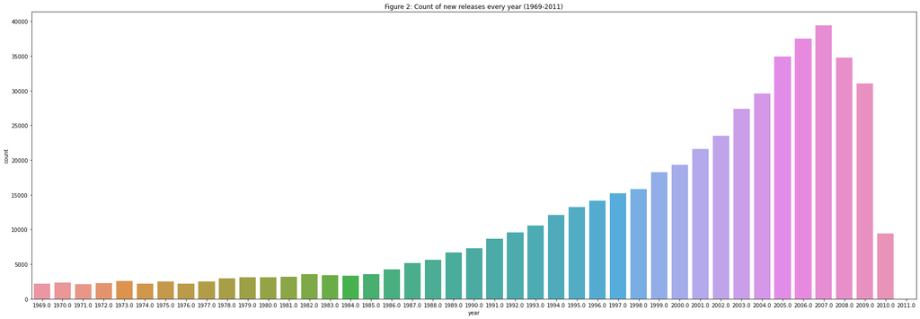

```python
release_year_df=pd.DataFrame(song_df['year'].value_counts())
release_year_df.drop(df.index[0],inplace=True)
release_year_df.reset_index(inplace=True)
release_year_df.columns=['year','count']
#release_year_df
plt.figure(figsize = (30, 10))
sns.barplot(data=release_year_df[release_year_df>1968],x='year',y='count')
plt.title('Figure 2: Count of new releases every year (1969-2011)')
```

#### **Observations and Insights:**

**Think About It:** What other insights can be drawn using exploratory data analysis?

- Here, I intend to find the most popular artists & albums

```python
df_final.head()
```

|  | user_id | song_id | play_count | title | release | artist_name | year |
| --- | --- | --- | --- | --- | --- | --- | --- |
| 200 | 6958 | 447 | 1 | Daisy And Prudence | Distillation | Erin McKeown | 2000 |
| 202 | 6958 | 512 | 1 | The Ballad of Michael Valentine | Sawdust | The Killers | 2004 |
| 203 | 6958 | 549 | 1 | I Stand Corrected (Album) | Vampire Weekend | Vampire Weekend | 2007 |
| 204 | 6958 | 703 | 1 | They Might Follow You | Tiny Vipers | Tiny Vipers | 2007 |
| 205 | 6958 | 719 | 1 | Monkey Man | You Know I'm No Good | Amy Winehouse | 2007 |

#### Top 20 most popular artists

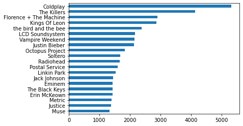

```python
# Most popular artists
df_final['artist_name'].value_counts()[:20].sort_values().plot(kind='barh')
```

```python
#### Top 20 most popular albums
```

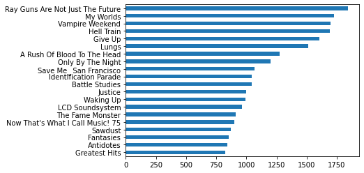

```python
# Most popular albums
df_final['release'].value_counts()[:20].sort_values().plot(kind='barh')
```

## **Proposed approach**

**Potential techniques:** What different techniques should be explored?

#### Now, data can be preprocessed based on play_count column in 2 ways.

- 1. Filtering data based on count (i.e. occurence of values of play_count)
- 1. Normalizing the play_count values in the range of 1-10 using MinMaxScaler()

##### 1. Filtering data based on count of play_count.

- In the above pre-processing task, we dropped records with play_count>5. But this can lead to unnecessary loss of information. For example, a play_count of 10 would indicate that a specific user has heard this particular song for 10 times, and it is his favourite!. In the given approach, this information would be lost.
- So a solution to this is, considering all the play_count record values, who have occured atleast 5 times! Filtering implemented below.
- Visualizing distribution of play_count
- It can be seen that there are very few records, where users have heard a particular song for thousands of times.
- A good idea would be to consider these as outliers, and not include them in our recommendation system.
- For this, we can consider all the play_count values, which have occured for atleast 5 times in our interaction dataset.
- Again 5 is an hyper parameter which can be tuned.

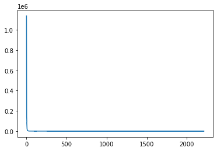

```python
final_df['play_count'].value_counts().plot()
```

- play_count values versus their counts sorted according to maximum play_count values

```python
play_count=final_df['play_count'].value_counts().reset_index().rename(columns={'index':'play_count','play_count':'Count'})
play_count.sort_values('play_count',ascending=False).head(15)
```

|  | play_count | Count |
| --- | --- | --- |
| 232 | 2213 | 1 |
| 264 | 920 | 1 |
| 245 | 879 | 1 |
| 276 | 796 | 1 |
| 225 | 683 | 1 |
| 240 | 676 | 1 |
| 238 | 664 | 1 |
| 235 | 649 | 1 |
| 244 | 605 | 1 |
| 256 | 585 | 1 |
| 242 | 553 | 1 |
| 193 | 500 | 2 |
| 261 | 488 | 1 |
| 222 | 455 | 1 |
| 231 | 453 | 1 |

- As we can see from the above plot and above table, there is 1 record which has a play_count of 2213, similarly very few (only 1/2) have a play count ranging between 500 to 1000
- play_count values sorted according to their count(number of occurances).
- Further, here also, we can consider only those play_count records which are more than 1.
- play_count of 1 would indicate that, a user has listened to the song only once and might have not liked this song!

```python
play_count.sort_values('Count',ascending=False).head(15)
```

|  | play_count | Count |
| --- | --- | --- |
| 0 | 1 | 1138433 |
| 1 | 2 | 313043 |
| 2 | 3 | 142933 |
| 3 | 5 | 93136 |
| 4 | 4 | 82569 |
| 5 | 6 | 45632 |
| 6 | 7 | 30920 |
| 7 | 8 | 22544 |
| 8 | 10 | 18921 |
| 9 | 9 | 16753 |
| 10 | 11 | 12531 |
| 11 | 12 | 9881 |
| 12 | 13 | 8025 |
| 13 | 15 | 6958 |
| 14 | 14 | 6476 |

- Both the above assumptions are considered in the following filtering implementation

```python
play_count[(play_count['Count']>5) & (play_count['play_count']>1)]
```

|  | play_count | Count |
| --- | --- | --- |
| 1 | 2 | 313043 |
| 2 | 3 | 142933 |
| 3 | 5 | 93136 |
| 4 | 4 | 82569 |
| 5 | 6 | 45632 |
| ... | ... | ... |
| 142 | 164 | 6 |
| 143 | 124 | 6 |
| 144 | 163 | 6 |
| 145 | 149 | 6 |
| 146 | 147 | 6 |

146 rows × 2 columns

##### Normalizing the play_count values in the range of 1-10 using MinMaxScaler()

- In this method, we can normalize all the play_count values ranging from (1 to 2213) into a smaller range(1-10) as indicated below

```python
df_scaled_play_count=final_df.copy(deep=True)
```

```python
from sklearn.preprocessing import MinMaxScaler
scaler=MinMaxScaler(feature_range=(1,10))
df_scaled_play_count['play_count_scaled']=scaler.fit_transform(np.array(df_scaled_play_count['play_count']).reshape(-1,1))
```

```python
df_scaled_play_count.head(10)
```

|  | user_id | song_id | play_count | title | release | artist_name | year | play_count_scaled |
| --- | --- | --- | --- | --- | --- | --- | --- | --- |
| 0 | 54961 | 153 | 1 | The Cove | Thicker Than Water | Jack Johnson | 0 | 1.000000 |
| 1 | 54961 | 413 | 2 | Entre Dos Aguas | Flamenco Para Niños | Paco De Lucia | 1976 | 1.004069 |
| 2 | 54961 | 736 | 1 | Stronger | Graduation | Kanye West | 2007 | 1.000000 |
| 3 | 54961 | 750 | 1 | Constellations | In Between Dreams | Jack Johnson | 2005 | 1.000000 |
| 4 | 54961 | 1188 | 1 | Learn To Fly | There Is Nothing Left To Lose | Foo Fighters | 1999 | 1.000000 |
| 5 | 54961 | 1239 | 5 | Apuesta Por El Rock 'N' Roll | Antología Audiovisual | Héroes del Silencio | 2007 | 1.016275 |
| 6 | 54961 | 1536 | 1 | Paper Gangsta | The Fame Monster | Lady GaGa | 2008 | 1.000000 |
| 7 | 54961 | 2056 | 1 | Stacked Actors | There Is Nothing Left To Lose | Foo Fighters | 1999 | 1.000000 |
| 8 | 54961 | 2220 | 1 | Sehr kosmisch | Musik von Harmonia | Harmonia | 0 | 1.000000 |
| 9 | 54961 | 3046 | 1 | Heaven's gonna burn your eyes | Hôtel Costes 7 by Stéphane Pompougnac | Thievery Corporation feat. Emiliana Torrini | 2002 | 1.000000 |

**Overall solution design:** What is the potential solution design?

- There are 3 different ways as shown above to pre-process the data and further, each of these data pre-processing methods can be used to implement following 3 types of recommendation systems algorithms
- 1. Rank Based Recommendation System
- 1. Collaborative Filtering Method a. User-User Based Similarity  
     b. Song-Song Based Similarity
- 1. Model based Recommendation System using Matrix Factorization (SVD)
- 1. Graph Neural Networks (Optional)

**Measures of success:** What are the key measures of success to compare different potential technqiues?

- The key measures of success to compare above potential technique would be as follows:
  1. Acuracy (R-squared, RMSE value)
     - The model would predict the play_count for the given users, based on KNN algorithm and similarity. This can be measured by using R-squared, RMSE, MAPE measures of success as play_count is a numeric quantity.
- 1. Precision
     - Depending on the range of play_count, I would decide a threshold to identify relevant items, for example, if I consider range of play_count as 1-10, then cut-off threshold would be around 5. Any predicted value above 5, that particular song, would be considered a potential song for recommendation.
     - Precision would correctly represent, out of recommended songs, which songs were actually heard by the users. So in this usecase, precision would be more useful.
     - Although, we can't completely ignore recall, as it would correctly represent the proportion of songs which were correctly recommended out of relevant songs. In such a case, we can strike a balance between Recall & Precision by using F1 score too